# notes5

### *Differential expression as a regression problem*

```r
setwd("C:/Users/seren/Desktop/Provero")
load("expr.RData")
head(expr)
```

```
##            mes1     mes2     mes3     mes4     mes5     mes6     neu1     neu2
## RNF14  8.102109 6.431024 7.233297 5.536356 7.980071 8.120170 6.807137 7.481830
## UBE2Q1 9.535052 9.531678 6.666299 6.934365 9.379369 9.046204 9.466937 9.369915
## RNF17  4.149430 4.374377 5.037466 5.135278 4.172273 4.529581 4.609084 4.456974
## RNF10  7.142845 6.882857 5.524656 6.236647 7.379514 6.893025 6.624718 7.057433
## RNF11  9.563294 8.782727 8.522499 6.927014 8.938691 8.707519 8.289256 9.274853
## RNF13  9.552312 9.237758 9.556759 7.951833 9.873957 9.457725 9.294424 9.016314
##             neu3      neu4     neu5      neu6
## RNF14   9.232656  8.474975 9.032406  8.901127
## UBE2Q1  9.171364  9.165563 9.742695  9.236809
## RNF17   4.161883  4.132093 4.293262  4.159367
## RNF10   6.897234  7.229054 6.788821  6.940517
## RNF11   9.317841  9.505812 9.941937  9.478019
## RNF13  10.465560 10.228730 9.599728 10.633883
```

We consider only one gene (the most significantly, differentially expressed one from last time):

```r
gene <- expr["SERPINC1", ]
#we did not set 'drop=FALSE', meaning that now 'gene' is no longer a matrix but a vector.

class(gene)
```

```
## [1] "numeric"
```

```r
gene
```

```
##     mes1     mes2     mes3     mes4     mes5     mes6     neu1     neu2
## 4.333796 4.124529 4.239739 4.120013 4.146627 4.238776 3.850684 3.856474
##     neu3     neu4     neu5     neu6
## 3.848018 3.712498 3.909699 3.727955
```

A t-test found this gene differentially expressed (between “mes” and “neu”):

```r
t.test(gene[1:6], gene[7:12])
```

```
##
##  Welch Two Sample t-test
##
## data:  gene[1:6] and gene[7:12]
## t = 8.1037, df = 9.9484, p-value = 1.086e-05
## alternative hypothesis: true difference in means is not equal to 0
## 95 percent confidence interval:
##  0.2776378 0.4884131
## sample estimates:
## mean of x mean of y
##  4.200580  3.817555
```

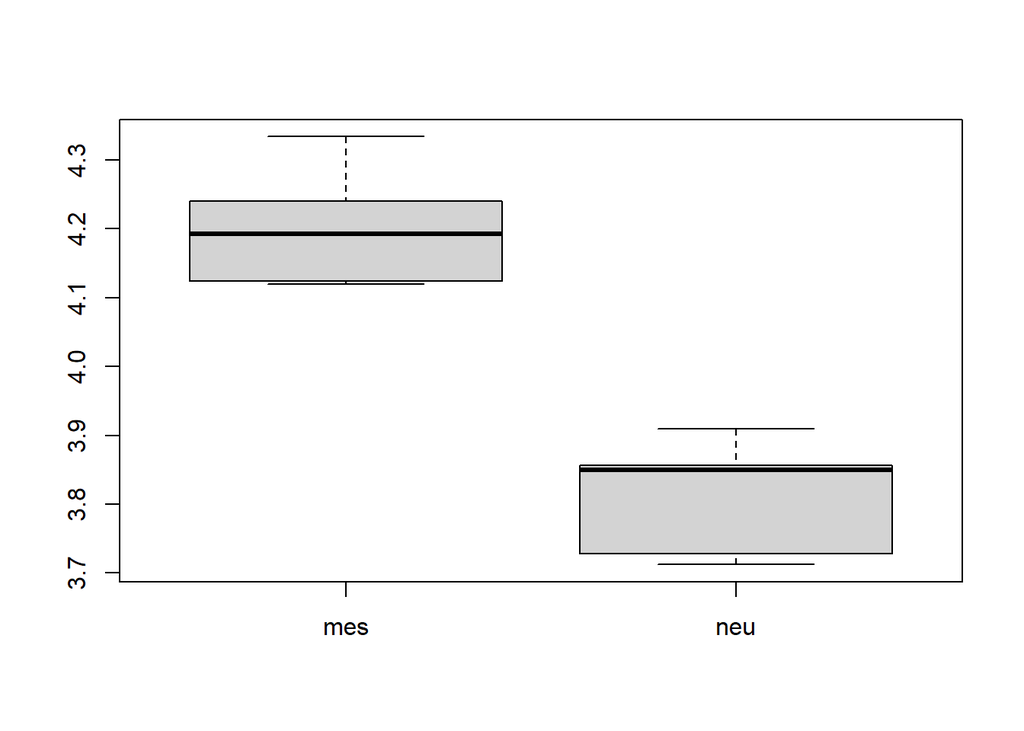

```r
boxplot(gene[1:6], gene[7:12], names = c("mes", "neu"))
```

This is a **regression problem**: is tumour type (categorical variable: either “mes” or “neu”) a *predictor* / *regressor* of the expression level of SERPINC1 (numerical variable)?

```r
type <- factor(c(rep("mes", 6), rep("neu", 6)))
#to first define the categorical variable tumour type,
#that should be a factor as Species for the iris dataset

class(type)
```

```
## [1] "factor"
```

```r
levels(type)
```

```
## [1] "mes" "neu"
```

```r
type
```

```
##  [1] mes mes mes mes mes mes neu neu neu neu neu neu
## Levels: mes neu
```

Now that we defined the categorical (binary) variable, let’s do the linear regression with our gene:

```r
gene_linreg <- lm(gene ~ type)
summary(gene_linreg)
```

```
##
## Call:
## lm(formula = gene ~ type)
##
## Residuals:
##      Min       1Q   Median       3Q      Max
## -0.10506 -0.07718  0.03180  0.03898  0.13322
##
## Coefficients:
##             Estimate Std. Error t value Pr(>|t|)
## (Intercept)  4.20058    0.03342 125.685  < 2e-16 ***
## typeneu     -0.38303    0.04727  -8.104 1.05e-05 ***
## ---
## Signif. codes:  0 '***' 0.001 '**' 0.01 '*' 0.05 '.' 0.1 ' ' 1
##
## Residual standard error: 0.08187 on 10 degrees of freedom
## Multiple R-squared:  0.8678, Adjusted R-squared:  0.8546
## F-statistic: 65.67 on 1 and 10 DF,  p-value: 1.052e-05
```

**Interpretation**: being “neu” decreases expression of SERPINC1 by 0.38 with respect to being “mes”. Uncertainty on this value is about 0.05. P-value suggests this effect is real.

Let’s compare this latter P-value with that retrieved with the t-test at the beginning:

```r
t.test(gene[1:6], gene[7:12])$p.value
```

```
## [1] 1.085867e-05
```

```r
summary(gene_linreg)$coefficients[2,4]
```

```
## [1] 1.051641e-05
```

The slight difference we can observe is due to the fact that the Welch t-test we used doesn’t assume the variance is independent of the *regressor* (`type` in this case) value, while the linear regression assumes same variance in “mes” and “neu”. To make the t-test assume this too, type:

```r
t.test(gene[1:6], gene[7:12], var.equal = TRUE)
```

```
##
##  Two Sample t-test
##
## data:  gene[1:6] and gene[7:12]
## t = 8.1037, df = 10, p-value = 1.052e-05
## alternative hypothesis: true difference in means is not equal to 0
## 95 percent confidence interval:
##  0.277712 0.488339
## sample estimates:
## mean of x mean of y
##  4.200580  3.817555
```

```r
#now it assumes the variance is the same in "mes" and "neu"
```

```r
t.test(gene[1:6], gene[7:12], var.equal = TRUE)$p.value
```

```
## [1] 1.051641e-05
```

```r
summary(gene_linreg)$coefficients[2,4]
```

```
## [1] 1.051641e-05
```

## 2. Logistic regression

We’ve said you can guess Sepal.Length better if you know Species, as Species is a significant *predictor* of Sepal.Length. Also the reverse is true (i.e. by knowing Sepal.Length you make a safer bet on the Species), so now we’ll regress/predict the categorical variable Species (dependent) on the numerical variable Sepal.Length (independent): this is done by **logistic regression** instead of linear regression.

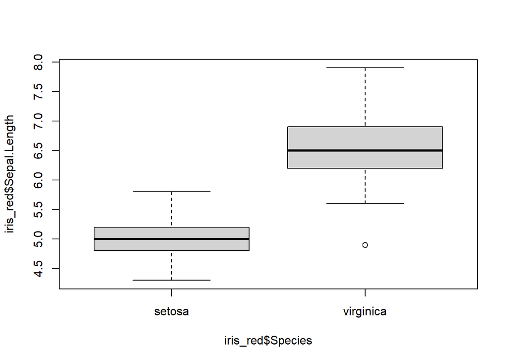

```r
plot(iris_red$Sepal.Length ~ iris_red$Species)
```

Logistic regression tells you the probability of being either “virginica” (=1) or “setosa” (=0) based on Sepal.Length. Since “virginica” = 1 and “setosa” = 0, we’re regressing a number (probability: 1 or 0, represented by the variable *num_species*) on a number (length of sepals). Probability is not that easy to regress (since it stays between 0 and 1), better to use its *logistic transform* (lt): $log(p/1-p)$

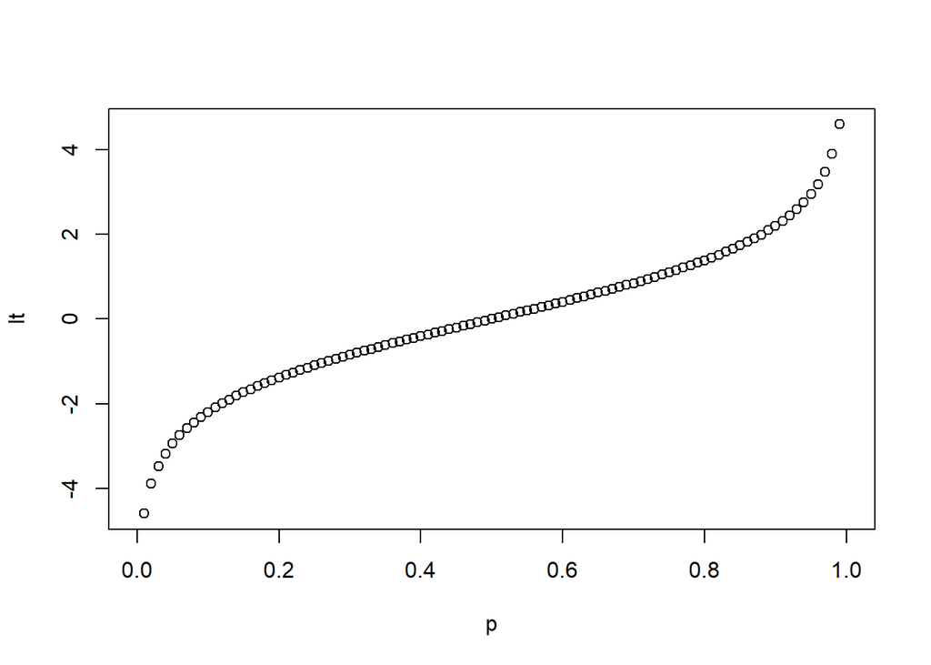

```r
p <- seq(from=0,to=1,by=0.01) #the probability is defined: it ranges from 0 to 1 (0.01 steps)
lt <- log(p/(1-p))  #we'll that the logistic transform varies between - infinite and + infinite
plot(x=p, y=lt)
```

This logistic transform of the probability of being either “virginica” (1) or “setosa” (0) has replaced the probability itself, and as the probability it is dependent on Sepal.Length:

$log(p/1-p)=\beta_{0}+\beta_{1}x$

Seems like a linear regression except for the fact that homoscedasticity is violated. We do logistic regression using the `glm()` function:

```r
logreg <- glm(iris_red$num_species ~ iris_red$Sepal.Length, family = "binomial")
summary(logreg)
```

```
##
## Call:
## glm(formula = iris_red$num_species ~ iris_red$Sepal.Length, family = "binomial")
##
## Deviance Residuals:
##     Min       1Q   Median       3Q      Max
## -1.5850  -0.1470  -0.0065   0.0824   3.2276
##
## Coefficients:
##                       Estimate Std. Error z value Pr(>|z|)
## (Intercept)            -38.547      9.557  -4.033 5.50e-05 ***
## iris_red$Sepal.Length    6.805      1.694   4.016 5.91e-05 ***
## ---
## Signif. codes:  0 '***' 0.001 '**' 0.01 '*' 0.05 '.' 0.1 ' ' 1
##
## (Dispersion parameter for binomial family taken to be 1)
##
##     Null deviance: 138.629  on 99  degrees of freedom
## Residual deviance:  26.247  on 98  degrees of freedom
## AIC: 30.247
##
## Number of Fisher Scoring iterations: 8
```

**Important**: `glm()` wants either a *logical* variable or a *numerical* variable taking values 0 or 1 (in our case, num_species is a numerical that can be only 1 or 0). The argument `family` should be specified because this function doesn’t do only logistic regression.

**Interpretation**: every 1 cm increase in Sepal.Length contributes to extra 6.805 units in the logistic transform of num_species (i.e. logistic transform of the probability of being either “virginica” or “setosa”).Uncertainty on the 6.805 value is about 1.7. P-value is low.

# Logistic *vs* Linear regression

If variable A gives info about variable B (i.e. A is *regressor* of B), also the reverse is true. It means that:

- linear regression to predict Sepal.Length from species (num_species)
- logistic regression to predict species (num_species) from Sepal.Length

both give the same information.